# Seattle Airbnbs Project

Karl Yang, Lin He, Peihuan Han, John Wang

5/20/2019

## Introduction

Seattle is an exciting city. Delicious food and beautiful seascapes have attracted tourists from all around the world. A comfortable and convenient place to stay during vacation can enhance tourists experience. Airbnb accommodations are spreading around the world and it allows people to discover enticing places and feel at home at the same time. Based on this, people coming to Seattle would like to choose high-cost performance Airbnb house instead of the traditional hotel. In this project, we will sort and analyze data collected by Airbnb in Seattle to help users explore popular neighborhoods based on their preference and find their best fit accommodations in Seattle.

The data was downloaded from [Seattle Airbnb Open Data](https://www.kaggle.com/airbnb/seattle#listings.csv). Seattle Airbnb Open Data was collected as part of the Airbnb Inside initiative. It described the listing activity of homestays in Seattle, WA.

## Summary Information

Based on the data collected by Airbnb in 2016, the average price of Airbnb accommodations in seattle is 127.98 US dollars and the average cleanning fee charged is 45.06 US dollars. The average minimum staying nights for living in Airbnb accomodations are 2 nights, and the maximum staying nights for living in Airbnb accomodations are 780 nights. In 2016, among all the Airbnb accommodations in seattle, *The El Rey in Frelard* is the most popular house with most review 12.15 per month among others.

## Summary Table by Room Types

Do you know which room type in Airbnb is most popular one in Seattle area? Which room type is the most expensive one? And which room type gives the best experience? To answer these question, we will create a summary table by grouping the airbnb rooms according to their room type so we can compare the difference between each room type easily!

| Room Type | Numbers Avaiable | Mean Rating | Review Number | Mean Price | Mean Cleaning Fee | Instant Bookable Rate |
| --- | --- | --- | --- | --- | --- | --- |
| Entire home/apt | 2541 | 94.48 | 52465 | $155.84 | $60.12 | 17.20% |
| Private room | 1160 | 94.80 | 30870 | $75.04 | $15.21 | 12.59% |
| Shared room | 117 | 93.23 | 1514 | $47.55 | $13.97 | 6.84% |

From the table above, we can see that the most popular room type of Airbnb in Seattle is definitely the entire home or the entire apartment, with the most number of rooms available and the largest number of reviews. Besides, it also has the highest rate of instant bookable rooms. However, it’s also the most expensive type of room, with both the highest mean price and highest cleaning fee. We can see its mean price is twice as much as Private rooms’ and three times as much as Share rooms.

So with the highest price and the most popularity, does the entire home/apartment also gives the best living experience? The data above tells us it’s not really true. In fact, from the table above we can see that private rooms’ mean rating is slightly higher than the entire home/apartment. Therefore, if you plan to travel Seattle with 1 or 2 persons, maybe private room is a good choice with good experience and cheaper prices; if you plan to travel with your entire family or lots of friends together, renting the entire home/apartment may be a good choice.

## All Airbnb Listings

Want to see all the listings on a map? Not problem! You can find all the listings below. You can get a good sense of the geographical distributon of the Airbnb listings in Seattle. A lot of listings are clustered in downtown seattle. You may find a lot of choice over there. You can click on the listing if you want to find more information. The popup window will provides you a thrumbnail image of the listing along with other useful information. If you want to find out more about the listing, you can click on the link which will bring you to Airbnb!

[interactive chart not shown]

According to the map, most of airbnbs are located in the north of Seattle, especially around capital hill, central distric and university district. Comparing to north of Seattle, there are fewer airbnbs in the south of Seattle.

[interactive chart not shown]

## Price

One bedroom house could not satisify you? Or you are coming with a large group. No problem! We will give you the pricing distribution divided by the number of bedrooms that allows you to make a better choice based on you budget. You are free to pick the number of bedrooms that best fits your need.

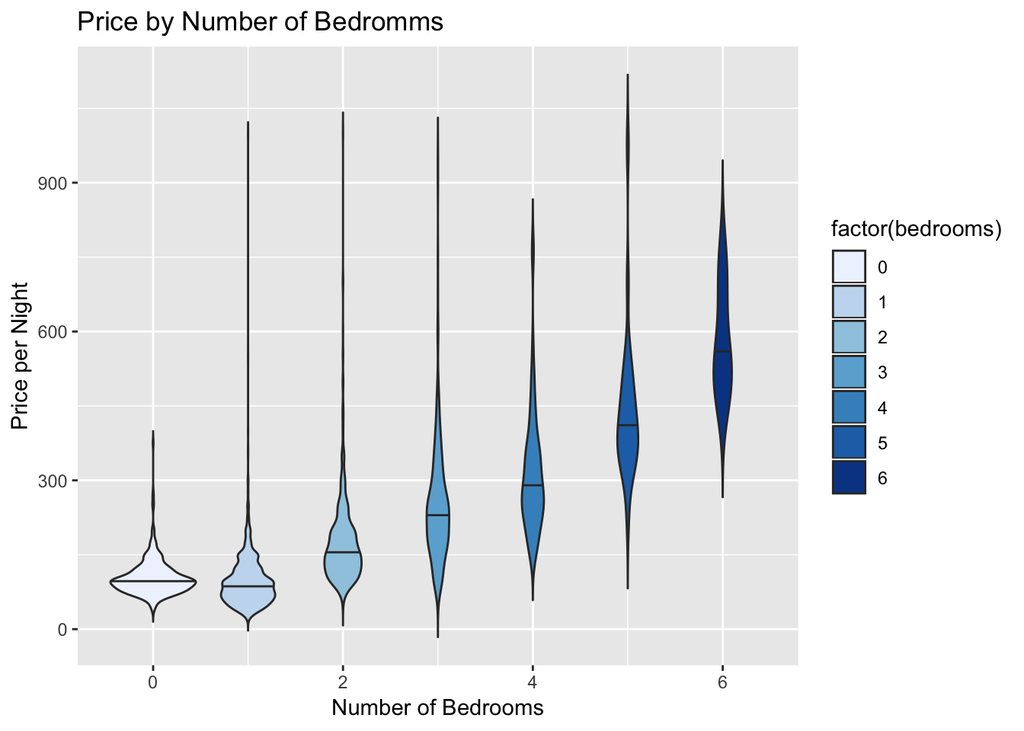

## Best Neighbourhoods

What? Budget is not a concern for you? You want the best of best experience. We have selcted five top-rating neigbourhood for you. You can activily look for places to stays in those communities.

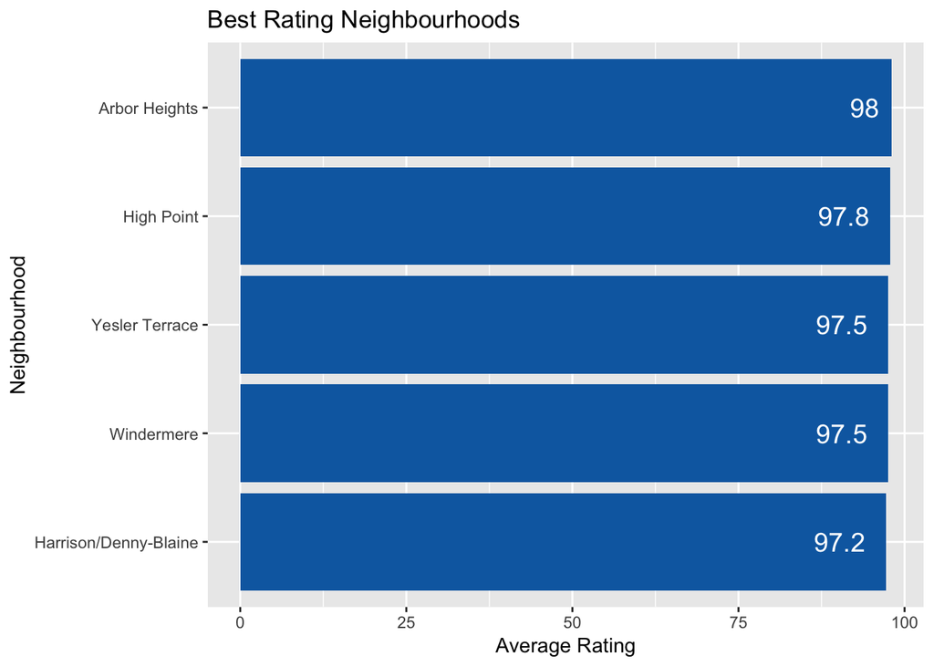

According to the chart, the Arbor Heights neightbourhood has the highest average rating of 98. The Harrison/Denny-Blaine neightbourhood has the lowest average rating of 97.2.